# DATASCI 350 - Data Science Computing

Lecture 07 - More Git Commands, CLI and Git Practice

Danilo Freire

danilo.freire@emory.edu

Department of Data and Decision Sciences  
Emory University

# Hello, everyone! 😊

# Recap and lecture overview 📚

## Recap of our last lecture

### In our last class, we covered

- How to `push` and `pull` changes to and from remote repositories
- Using `.gitignore` to avoid tracking certain files
- Creating and managing branches with `git branch` and `git checkout`
- The difference between `clone` and `fork` repositories
- Resolving conflicts when multiple people change the same code
- Going back to specific commits with `git checkout` and `git reset`
- Workflow for merging branches back to `master/main`

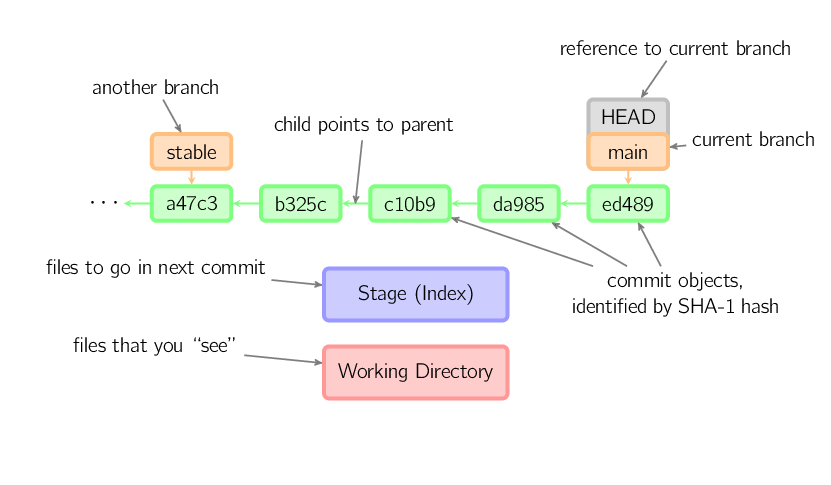

Source: [Lodato (2010)](https://marklodato.github.io/visual-git-guide/index-en.html)

## Today’s lecture

Today we will cover:

- Understanding changes with `git diff`
- Amending commits with `git commit --amend`
- Cherry-picking commits with, well, `git cherry-pick` 😅
- Understanding `git rebase` and its uses
- Saving work temporarily with `git stash`
- Installing and setting up GitHub CLI
- GitHub CLI repository management
- Mock-up quiz!

[figure not shown]

[figure not shown]

# Understanding changes with git diff 🔍

## What is `git diff`?

- `git diff` shows what has changed, line by line
- It compares your working directory, the staging area, commits, or branches
- Read it before every commit. It is the cheapest way to catch a mistake
- Let’s make a change in `my-project` and look at it

```bash
echo "# This is a data cleaning script" >> ./01-data-cleaning.py
git diff
```

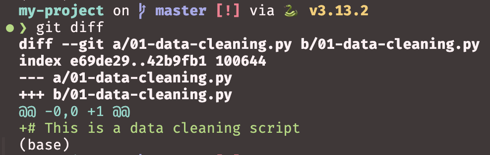

Reading the output:

- `a/` is the old version, `b/` is the new one
- `@@ -0,0 +1 @@` gives the line numbers: none before, one line now
- `+` marks an added line, `-` a deleted one

## Common `git diff` commands

**Basic diff commands:**

- `git diff`: shows unstaged changes in working directory
- `git diff --staged`: shows staged changes ready to commit
- `git diff HEAD`: shows all changes since last commit
- `git diff --name-only`: shows only filenames that changed

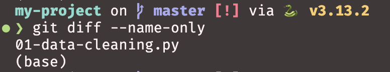

**Comparing commits:**

- `git diff commit1..commit2`: compares two specific commits
- `git diff branch1..branch2`: compares two branches
- `git diff --stat`: shows summary of changes (files modified, insertions, deletions)

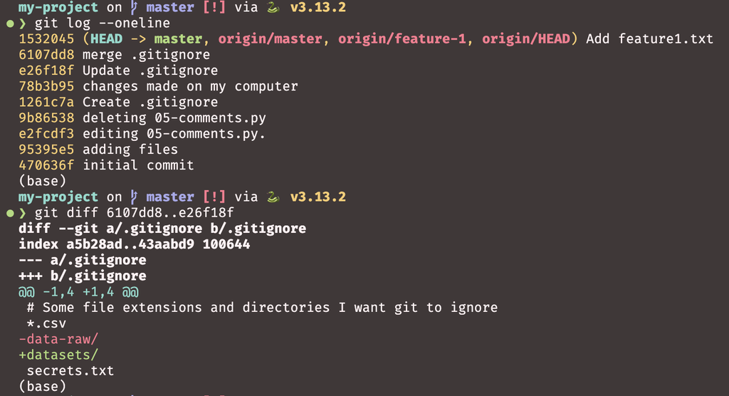

- `@@ -1,4 +1,4 @@` means that in the original file, lines 1 to 4 were present, and in the new file, lines 1 to 4 are also present, but with some changes

# Amending and undoing commits

## What is `git commit --amend`?

- `git commit --amend` rewrites your last commit
- Use it when you mistyped the message, or forgot to add a file
- Whatever is staged gets folded into the previous commit
- Only amend commits you have not pushed. Rewriting shared history causes trouble for everyone else

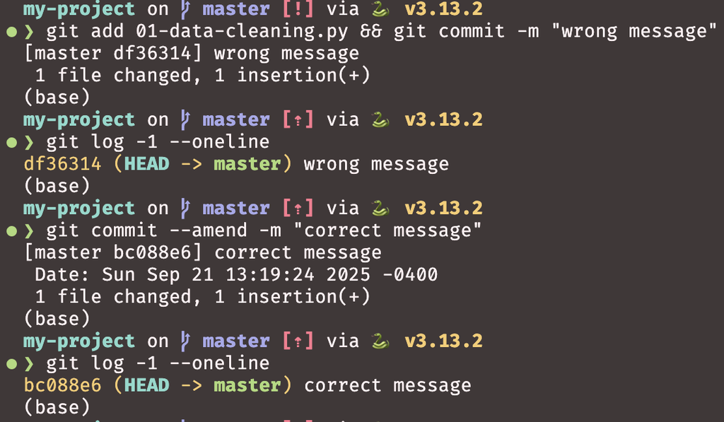

## How to amend commits

**Amending the commit message:**

```bash
git commit --amend -m "New commit message"
```

**Adding forgotten files:**

```bash
git add forgotten-file.txt
git commit --amend --no-edit
```

**Both together:**

```bash
git add new-file.txt
git commit --amend -m "Updated commit message"
```

**Important rules:**

- Only amend local commits
- Never amend commits that have been pushed to a shared repository
- If you need to modify pushed commits, use `git revert` instead
- Always communicate with your team before amending shared history

## Undoing commits with `git reset`

- If you made a mistake, git allows you to undo commits
- `git reset` can move the HEAD pointer to a previous commit
- `--soft` keeps your changes staged
- `--mixed` (the default) keeps them, but unstaged
- `--hard` throws them away entirely
- Use with caution too! Hard reset will delete uncommitted changes

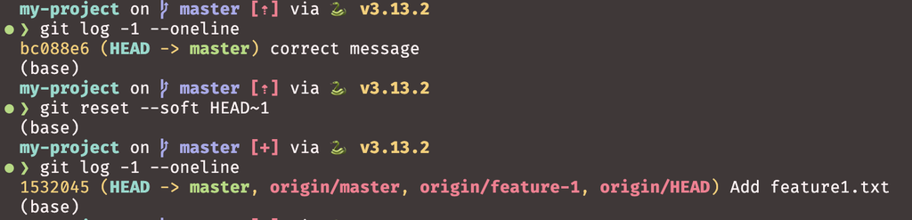

**Undo last commit but keep changes:**

```bash
git reset --soft HEAD~1
```

**Undo last commit and discard changes:**

```bash
git reset --hard HEAD~1
```

- You can undo as many commits as needed by changing the number after `HEAD~`, such as `HEAD~2` for the last two commits

# Cherry-picking commits

## What is `git cherry-pick`?

- `git cherry-pick` allows you to pick specific commits from one branch and apply them to another
- Useful when you want to apply a bug fix or feature from one branch to another
- Each commit is applied individually with its own commit message
- Can be used to backport changes to older versions
- Creates new commits rather than modifying existing ones

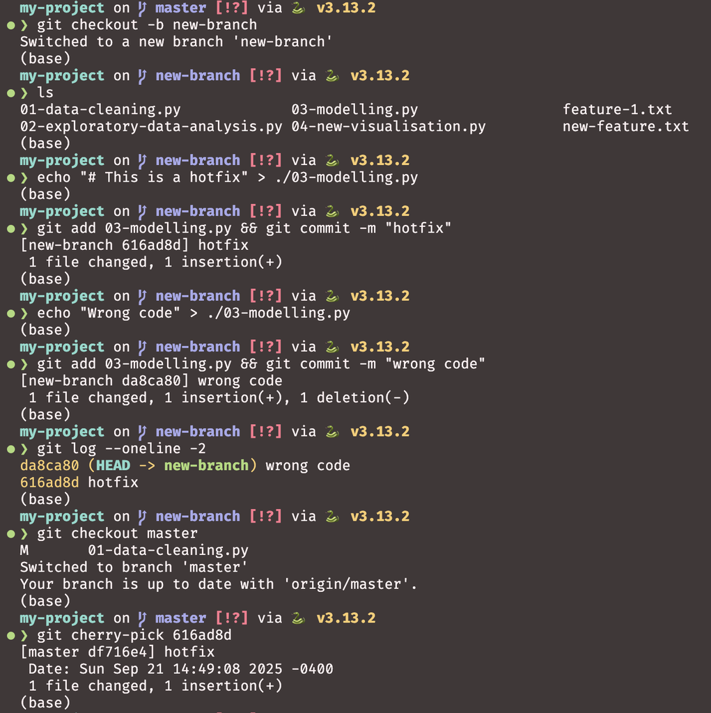

## Using `git cherry-pick`

**Basic cherry-pick:**

```bash
# Cherry-pick a single commit
git cherry-pick abc1234

# Cherry-pick multiple commits
git cherry-pick abc1234 def5678

# Cherry-pick a range of commits
git cherry-pick abc1234..def5678
```

**After cherry-picking:**

- The commit is applied to your current branch
- It creates a new commit with the same changes
- Original commit history is preserved

**Handling conflicts:**

```bash
# If conflicts occur during cherry-pick
git cherry-pick --continue  # After resolving conflicts
git cherry-pick --abort     # Cancel the cherry-pick
git cherry-pick --skip      # Skip the current commit
```

**Common use cases:**

- Applying hotfixes to multiple branches
- Backporting features to release branches
- Moving specific commits between branches

# Understanding git rebase

## Understanding `git rebase`

- `git rebase` allows you to move or combine commits to a new base commit
- Changes the commit history by replaying commits on top of another base
- Creates a linear, clean commit history
- Useful for keeping feature branches up to date with main branch
- Rewrites commit history - avoid using it on shared or public branches!

[figure not shown]

## Types of rebasing

**Interactive rebase:**

```bash
# Interactive rebase of last 3 commits
git rebase -i HEAD~3

# Interactive rebase to specific commit
git rebase -i abc1234
```

**Rebase onto another branch:**

```bash
# Rebase current branch onto main
git rebase main

# Rebase feature branch onto main
git checkout feature-branch
git rebase main
```

**During interactive rebase you can:**

- `pick`: use the commit as-is
- `reword`: change the commit message
- `edit`: modify the commit contents
- `squash`: combine with the previous commit
- `drop`: remove the commit entirely
- To reorder commits, move the lines themselves

# Saving work with git stash

## What is `git stash`?

- `git stash` puts your uncommitted changes aside, leaving a clean working directory
- Think of it as a clipboard for work in progress
- Stashes pile up in a stack, so the last one you saved is the first one back

**Use it when:**

- An urgent fix arrives and you are mid-way through something else
- You want to `pull` but have local changes in the way
- You are experimenting and want to park the experiment
- You started work on the wrong branch

```bash
# You're working on a feature
echo "new feature code" >> feature.py

# Suddenly need to switch branches
git stash

# Your working directory is now clean!
git checkout main
# Do your hotfix work...

# Return to your feature branch
git checkout feature-branch
git stash pop  # Restore your changes
```

## Basic `git stash` commands

**Saving and restoring stashes:**

```bash
# Stash current changes (tracked files only)
git stash

# Stash with a descriptive message
git stash push -m "WIP: adding user authentication"

# Stash including untracked files
git stash -u

# Stash including untracked and ignored files
git stash -a

# Restore most recent stash and remove from stack
git stash pop

# Restore most recent stash but keep in stack
git stash apply
```

**Managing multiple stashes:**

```bash
# List all stashes
git stash list

# Apply a specific stash
git stash apply stash@{2}

# Drop a specific stash
git stash drop stash@{1}

# Clear all stashes (use with caution!)
git stash clear

# Show changes in most recent stash
git stash show

# Show changes in stash with diff
git stash show -p stash@{0}
```

## Moving changes to another branch with `git stash`

**A very common scenario:**

You’ve been coding away, only to realise you’re on the wrong branch! 😱

`git stash` makes it easy to move your uncommitted changes to the correct branch:

```bash
# You're on main but should be on feature-x
# First, stash your changes
git stash push -m "Move to feature-x branch"

# Switch to the correct branch
git checkout feature-x

# Apply your stashed changes
git stash pop
```

This technique works for both tracked and untracked files (use `git stash -u` for untracked).

**Creating a new branch from stash:**

If the branch doesn’t exist yet, you can create it directly from the stash:

```bash
# Stash your current work
git stash

# Create new branch with stashed changes
git stash branch new-feature-branch
```

This command:

- Creates a new branch from where you stashed
- Checks out the new branch
- Applies the stash
- Drops the stash if applied successfully

Pro tip: This is the safest way to recover stashed work if you’re unsure about conflicts!

# GitHub CLI - Installation 🖥️

## GitHub in the terminal

- GitHub CLI (`gh`) is the official command-line tool for GitHub
- It does from the terminal what you would otherwise do in a browser: repositories, issues, pull requests
- Do not type the WSL command below. Copy it from https://cli.github.com/

**macOS (using Homebrew):**

```bash
# /bin/bash -c "$(curl -fsSL https://raw.githubusercontent.com/Homebrew/install/HEAD/install.sh)"
brew install gh
```

**WSL/Ubuntu:**

```bash
# Install
(type -p wget >/dev/null || (sudo apt update && sudo apt install wget -y)) \
    && sudo mkdir -p -m 755 /etc/apt/keyrings \
    && out=$(mktemp) && wget -nv -O$out https://cli.github.com/packages/githubcli-archive-keyring.gpg \
    && cat $out | sudo tee /etc/apt/keyrings/githubcli-archive-keyring.gpg > /dev/null \
    && sudo chmod go+r /etc/apt/keyrings/githubcli-archive-keyring.gpg \
    && sudo mkdir -p -m 755 /etc/apt/sources.list.d \
    && echo "deb [arch=$(dpkg --print-architecture) signed-by=/etc/apt/keyrings/githubcli-archive-keyring.gpg] https://cli.github.com/packages stable main" | sudo tee /etc/apt/sources.list.d/github-cli.list > /dev/null \
    && sudo apt update \
    && sudo apt install gh -y

# Update (if already installed)
sudo apt update && sudo apt install gh -y
```

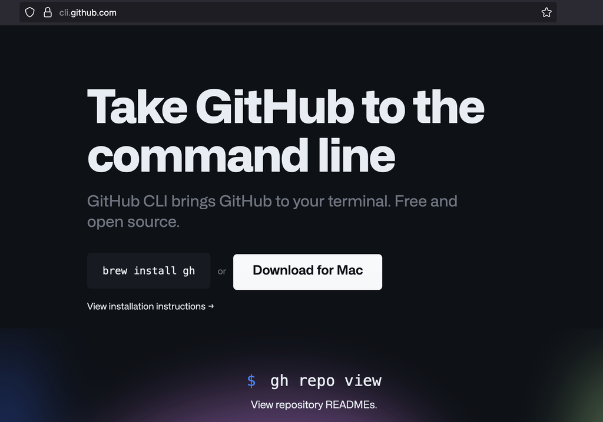

Website: https://cli.github.com/

**Verify installation:**

```bash
gh --version
```

## How to connect your terminal to GitHub

**Authenticate with GitHub:**

```bash
gh auth login
```

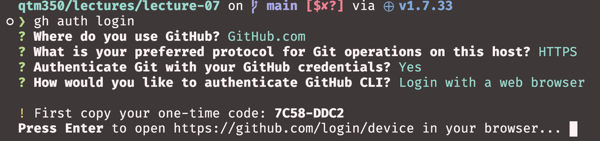

- And you’re all set to use GitHub CLI! 🎉

## Working with repositories, pull requests, and issues

**Repository operations:**

```bash
# List your repositories
gh repo list

# Clone a repository
gh repo clone username/repo-name

# Create a new repository
gh repo create

# View repository details
gh repo view --web

# Fork a repository
gh repo fork

# Star/unstar a repository
gh repo star

# Archive/unarchive a repository
gh repo archive
```

**Pull requests and issues:**

```bash
# Create a new pull request
gh pr create --title "My PR" --body "Description of my PR"

# List pull requests
gh pr list

# View pull request details
gh pr view 123 --web

# Create a new issue
gh issue create --title "My Issue" --body "Description of my issue"

# List issues
gh issue list

# View issue details
gh issue view 456 --web
```

# GitHub CLI - Practical Examples 💡

## Real-world GitHub CLI usage

```bash
mkdir new-project && cd new-project
echo "# New project" > README.md
git init && git add . && git commit -m "first commit"
```

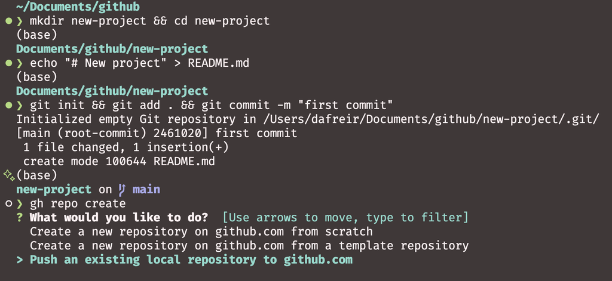

```bash
gh repo create
# Follow the prompts
gh repo view --web
```

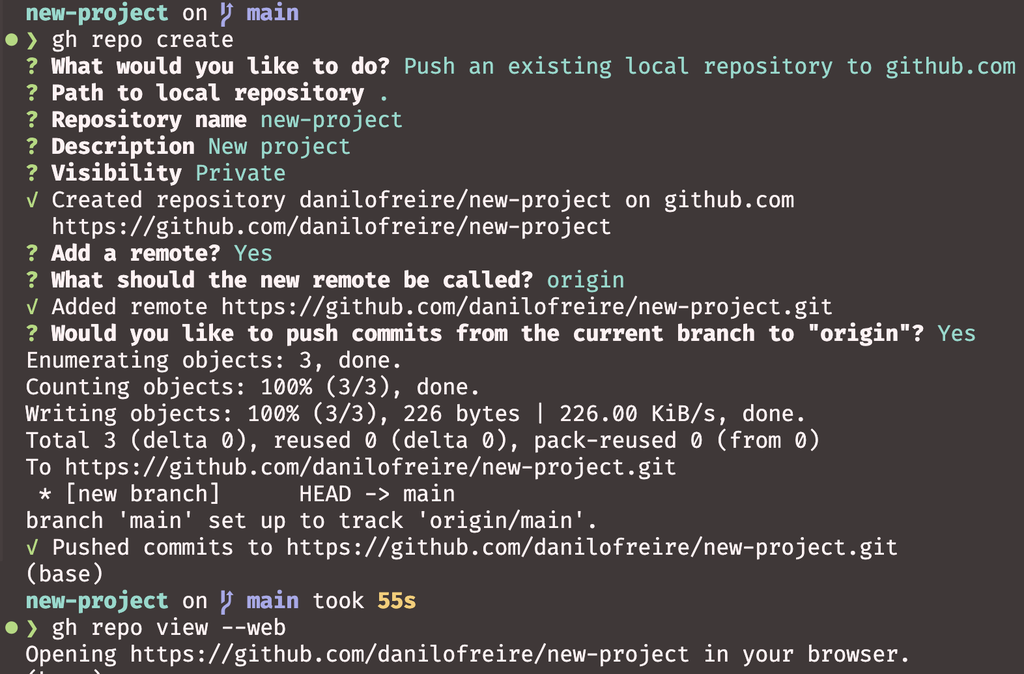

## Goodbye, GitHub Desktop! 👋

[figure not shown]

# Practice Time! ⏱️

## Git practice quiz

Set up the repository

1. Create a `git-practice` directory and initialise it
2. Add a `README.md` containing `# Git Practice Repository`
3. Create `src/main.py`, empty
4. Commit everything: “Initial commit with README and main.py”

Work on a branch

5. Create and switch to a branch called `hotfix`
6. In `src`, use brace expansion to create `utils.js`, `utils.css`, and `utils.html` in one command
7. Add a `.gitignore` containing `temp/`, then commit: “Add hotfix files and gitignore”
8. Rename `src/main.py` to `src/app.py`
9. Commit: “Complete hotfix development”

Bring it back

10. Switch back to your default branch, merge `hotfix`, and show the history in compact form

Check your work with `git log --oneline` and `git branch`

# And that’s a wrap! 🎉

# Appendix: Quiz answers

## Solutions to practice quiz

Here are the answers to the practice quiz. Try to complete the quiz first before checking these answers!

1. `mkdir git-practice && cd git-practice && git init`
2. `echo "# Git Practice Repository" > README.md`
3. `mkdir src && touch src/main.py`
4. `git add . && git commit -m "Initial commit with README and main.py"`
5. `git checkout -b hotfix`
6. `touch src/utils.{js,css,html}`
7. `echo "temp/" > .gitignore && git add . && git commit -m "Add hotfix files and gitignore"`
8. `mv src/main.py src/app.py`
   - `git mv src/main.py src/app.py` does the same and stages it in one step
9. `git add . && git commit -m "Complete hotfix development"`
10. `git checkout main && git merge hotfix && git log --oneline`
    - If `git init` gave you a branch called `master`, use that name instead. Check with `git branch`

**Additional verification commands:**

- Check commit history: `git log --oneline`
- View file structure: `ls -la`
- Check branch status: `git branch`
- View .gitignore contents: `cat .gitignore`